# Data i dialog

Visualisering av data från Skolverket

Author

Affiliation

Magnus Johansson

[RISE Research Institutes of Sweden](https://www.ri.se/sv/vad-vi-gor/expertiser/kategoriskt-baserade-matningar)

Published

2023-09-19

```r
årtal <- c(2006,2008,2010,2012,2014,2016,2018,2020,2022)

fokusKommun <- "Sigtuna"
jmfKommun <- c("Järfälla","Sigtuna")
source("DIDreportSetup.R")
source("DIDreportFunctions.R")

### set up color palette based on RISE guidelines
RISEprimGreen <- "#009ca6"
RISEprimRed <- "#e83c63"
RISEprimYellow <- "#ffe500"
RISEprimGreenMid <- "#8dc8c7"
RISEprimRedMid <- "#f5a9ab"
RISEprimYellowMid <- "#ffee8d"
RISEprimGreenLight <- "#ebf5f0"
RISEprimRedLight <- "#fde8df"
RISEprimYellowLight <- "#fff7dd"
RISEcompPurple <- "#482d55"
RISEcompGreenDark <- "#0e4e65"
RISEgrey1 <- "#f0f0f0"
RISEgrey2 <- "#c8c8c8"
RISEgrey3 <- "#828282"
RISEgrey4 <- "#555555"

### colors specifically for DID application
DIDcolorsOriginal <- c('#D55E00','#F0E442','#009E73','#999999')
DIDcolors <- lighten(DIDcolorsOriginal, amount = 0.1, space = "HLS")
DIDred <- "#D55E00"
DIDorange <- "#E69F00"
DIDgreen <- "#009E73"
DIDyellow <- "#F0E442"

demogr.skolverket <- read_parquet("Skolverket/skolverketDemografi.parquet")
sigtuna.skolverket <- read_parquet("Skolverket/2023-08-21_SkolverketData_Sigtuna.parquet")
```

## 1 Variabler

```r
sigtuna.skolverket %>%
  distinct(variable)
```

```
# A tibble: 20 × 1
   variable
   <chr>
 1 specialTeacherPositions
 2 studentsPerTeacherQuota
 3 certifiedTeachersQuota
 4 totalNumberOfPupils
 5 specialEducatorsQuota
 6 ratioOfPupilsIn6thGradeWithAllSubjectsPassed
 7 averageResultNationalTestsSubjectSVE6thGrade
 8 averageResultNationalTestsSubjectENG6thGrade
 9 averageResultNationalTestsSubjectMA6thGrade
10 averageResultNationalTestsSubjectSVA6thGrade
11 averageResultNationalTestsSubjectSVE9thGrade
12 averageResultNationalTestsSubjectENG9thGrade
13 averageResultNationalTestsSubjectMA9thGrade
14 averageResultNationalTestsSubjectSVA9thGrade
15 ratioOfPupilsIn9thGradeWithAllSubjectsPassed
16 averageGradesMeritRating9thGrade
17 ratioOfPupils9thGradeEligibleForNationalProgramYR
18 ratioOfPupils9thGradeEligibleForNationalProgramES
19 ratioOfPupils9thGradeEligibleForNationalProgramSAEKHU
20 ratioOfPupils9thGradeEligibleForNationalProgramNATE
```

Vi behöver ordna svenska beteckningar på dessa variabler.

```r
itemlabels <- data.frame(
  variable = sigtuna.skolverket %>%
    distinct(variable) %>%
    pull(variable),
  description = c("Antal specialpedagoger",
                  "Elever per lärare",
                  "Andel legitimerade lärare",
                  "Totalt antal elever",
                  "Elever per specialpedagog",
                  "Andel elever i 6:e klass med fullständiga betyg",
                  "Medelvärde nationella prov svenska 6:e klass",
                  "Medelvärde nationella prov engelska 6:e klass",
                  "Medelvärde nationella prov matematik 6:e klass",
                  "Medelvärde nationella prov SVA 6:e klass",
                  "Medelvärde nationella prov svenska 9:e klass",
                  "Medelvärde nationella prov engelska 9:e klass",
                  "Medelvärde nationella prov matematik 9:e klass",
                  "Medelvärde nationella prov SVA 9:e klass",
                  "Andel elever i 9:e klass med fullständiga betyg",
                  "Medelvärde meritvärde",
                  "Andel elever i 9:e klass behöriga till yrkesprogram",
                  "Andel elever i 9:e klass behöriga till estetiskt program",
                  "Andel elever i 9:e klass behöriga till sam/ek/hum",
                  "Andel elever i 9:e klass behöriga till natur/teknik"
                  )
)

sigtuna.skolverket <- left_join(sigtuna.skolverket,itemlabels, by = "variable")
#write_csv(itemlabels, "Skolverket/SkolverketItemlabels.csv")
```

## 2 Skolor och områden

Det finns tre skoltyper i data:

```r
sigtuna.skolverket %>%
  distinct(type)
```

```
# A tibble: 3 × 1
  type
  <chr>
1 fsk
2 gr
3 gy
```

Vi börjar med grundskolan (type == “gr”).

```r
gr.sigtuna.skolverket <- sigtuna.skolverket %>%
  filter(type == "gr")
#write_parquet(gr.sigtuna.skolverket, "Skolverket/SkolverketSigtunaGrundskolor.parquet")
```

Sigtuna har uppgett att de vill använda en områdesindelning enligt nedan.

```r
sOmråden <- data.frame(
  stringsAsFactors = FALSE,
                        Område = c("Centrala Märsta","Ekilla och Tingvalla","Sigtuna",
                                   "Sigtuna","Sigtuna","Sigtuna","Sigtuna",
                                   "Steninge","Valsta","Valsta"),
                      Skolnamn = c("Centralskolan","Ekillaskolan","St Olofs skola",
                                   "Sigtunaskolan hum. läroverket gr",
                                   "Sigtunaskolan hum. läroverket gy",
                                   "Sigtunaskolan hum. läroverket int gr",
                                   "Sigtunaskolan hum. läroverket int gy","Steningehöjdens skola",
                                   "Arlandagymnasiet","Valstaskolan")
            )
kbl_rise(sOmråden)
```

| Område | Skolnamn |
| --- | --- |
| Centrala Märsta | Centralskolan |
| Ekilla och Tingvalla | Ekillaskolan |
| Sigtuna | St Olofs skola |
| Sigtuna | Sigtunaskolan hum. läroverket gr |
| Sigtuna | Sigtunaskolan hum. läroverket gy |
| Sigtuna | Sigtunaskolan hum. läroverket int gr |
| Sigtuna | Sigtunaskolan hum. läroverket int gy |
| Steninge | Steningehöjdens skola |
| Valsta | Arlandagymnasiet |
| Valsta | Valstaskolan |

Vi inför en områdesvariabel i Skolverkets data utifrån detta. Först behöver vi se om/hur skolnamnen matchar, och koda om efter behov.

```r
gr.sigtuna.skolverket %>%
  distinct(Skolenhetsnamn) %>%
  arrange(Skolenhetsnamn) %>%
  kbl_rise()
```

| Skolenhetsnamn |
| --- |
| Centralskolan |
| Eddaskolan |
| Ekillaskolan |
| Galaxskolan |
| Internationella Engelska Skolan Sigtuna |
| Josefinaskolan, grundskola |
| Norrbackaskolan |
| Odensala skola |
| Råbergsskolan |
| S:t Olofs skola |
| S:t Pers skola |
| S:ta Gertruds skola |
| Sagaskolan |
| Sigtunaskolan hum. läroverket, gr |
| Sigtunaskolan hum. läroverket, int gr |
| Skepptuna skola |
| Skolan Bergius |
| Steningehöjdens skola |
| Sätunaskolan |
| Tingvallaskolan |
| Väringaskolan |

Vi ser här att det finns med en skola som saknas i både TTS(?) och Stockholmsenkäten, “Skolan Bergius”, som läggs till under “Centrala Märsta” utifrån mailväxling.

```r
sOmråden <- rbind(sOmråden,c("Centrala Märsta","Skolan Bergius"))
```

Omkodningar enligt nedan.

```r
gr.sigtuna.skolverket <- gr.sigtuna.skolverket %>%
  rename(Skolnamn = Skolenhetsnamn) %>%
  mutate(Skolnamn = car::recode(Skolnamn,"'Sigtunaskolan hum. läroverket, gr'='Sigtunaskolan hum. läroverket gr';'Sigtunaskolan hum. läroverket, int gr'='Sigtunaskolan hum. läroverket int gr'")) %>%
  mutate(Skolnamn = gsub(":","",Skolnamn))
```

Nu kan vi lägga till områdesvariabeln i data.

```r
gr.sigtuna.skolverket <- left_join(gr.sigtuna.skolverket,sOmråden, by = "Skolnamn")
```

Och räkna fram oviktade och viktade medelvärden för respektive område och variabel.

```r
gr.sigtuna.skolverket %>%
  filter(variable == "totalNumberOfPupils") %>%
  distinct(timePeriod)
```

```
# A tibble: 1 × 1
  timePeriod
       <int>
1       2022
```

Men data saknar tyvärr information om antal elever förutom för 2022. Vi kanske kan importera den informationen från Skolverkets demografiska data.

```r
demogr.skolverket %>%
  filter(skolkommun == "Sigtuna") %>%
  distinct(skola) %>%
  kbl_rise()
```

| skola |
| --- |
| Centralskolan |
| Eddaskolan |
| Ekillaskolan |
| Josefinaskolan, grundskola |
| Norrbackaskolan |
| Odensala skola |
| Rävsta skola |
| Råbergsskolan |
| S:t Olof |
| S:t Pers skola |
| S:ta Gertruds skola |
| Sagaskolan |
| Sigtunaskolan hum. läroverket |
| Skepptuna skola |
| Skolan Bergius |
| Steningeskolan |
| Sätunaskolan |
| Tingvallaskolan |
| Valstaskolan |
| Väringaskolan |
| Sigtunaskolan hum. läroverket, gr |
| S:t Olofs skola |
| Steningehöjdens skola |
| Valstaskolan 4-6 |
| Valstaskolan 7-9 |
| Galaxskolan |
| Sigtunaskolan hum. läroverket, int gr* |
| Internationella Engelska Skolan Sigtuna |

Verkar vara NÄSTAN samma som tidigare…

```r
sigtuna.demogr <- demogr.skolverket %>%
  filter(skolkommun == "Sigtuna") %>%
  rename(Skolnamn = skola,
         studentN = elever_arskurs_1_9) %>% #distinct(Skolnamn) %>% kbl_rise()
  mutate(År = year - 1) %>%  # 2022/2023 är kodat som 2023 i data, pga jämförbarhet m Sthlmsenkäten som samlas in på vårterminen
  mutate(Skolnamn = car::recode(Skolnamn,"'Sigtunaskolan hum. läroverket, gr'='Sigtunaskolan hum. läroverket gr';'Sigtunaskolan hum. läroverket, int gr*'='Sigtunaskolan hum. läroverket int gr'")) %>%
  mutate(Skolnamn = gsub(":","",Skolnamn)) %>%
  select(År,Skolnamn,studentN)

gr.sigtuna.skolverket <- gr.sigtuna.skolverket %>%
  rename(År = timePeriod)
```

```r
gr.sigtuna.skolverket <- left_join(gr.sigtuna.skolverket,sigtuna.demogr, by = c("År","Skolnamn"))
```

För skojs skull kan vi jämföra Skolverket egna data om antal elever för 2022, baserat på deras två datakällor för grundskolan.

```r
gr.sigtuna.skolverket %>%
  filter(variable == "totalNumberOfPupils") %>%
  # Skolnamn %in% sOmråden$Skolnamn) %>%
  select(variable, value, studentN, Skolnamn, År) %>%
  mutate(Differens = sqrt((value - studentN) ^ 2), .after = "studentN") %>%
  rename(
    SkolverketAPI = value,
    SkolverketDemografi = studentN
  ) %>%
  arrange(desc(Differens)) %>%
  kbl_rise() %>%
  column_spec(
    column = 4,
    bold = T
  )
```

| variable | SkolverketAPI | SkolverketDemografi | Differens | Skolnamn | År |
| --- | --- | --- | --- | --- | --- |
| totalNumberOfPupils | 290 | 285 | 5 | Galaxskolan | 2022 |
| totalNumberOfPupils | 400 | 395 | 5 | St Olofs skola | 2022 |
| totalNumberOfPupils | 130 | 126 | 4 | Odensala skola | 2022 |
| totalNumberOfPupils | 420 | 424 | 4 | Ekillaskolan | 2022 |
| totalNumberOfPupils | 310 | 314 | 4 | Sagaskolan | 2022 |
| totalNumberOfPupils | 300 | 297 | 3 | Sätunaskolan | 2022 |
| totalNumberOfPupils | 310 | 307 | 3 | Norrbackaskolan | 2022 |
| totalNumberOfPupils | 200 | 197 | 3 | Väringaskolan | 2022 |
| totalNumberOfPupils | 320 | 317 | 3 | Tingvallaskolan | 2022 |
| totalNumberOfPupils | 80 | 83 | 3 | Skepptuna skola | 2022 |
| totalNumberOfPupils | 110 | 107 | 3 | Sigtunaskolan hum. läroverket gr | 2022 |
| totalNumberOfPupils | 250 | 252 | 2 | Sta Gertruds skola | 2022 |
| totalNumberOfPupils | 510 | 512 | 2 | Internationella Engelska Skolan Sigtuna | 2022 |
| totalNumberOfPupils | 200 | 198 | 2 | Josefinaskolan, grundskola | 2022 |
| totalNumberOfPupils | 60 | 62 | 2 | Sigtunaskolan hum. läroverket int gr | 2022 |
| totalNumberOfPupils | 470 | 468 | 2 | Centralskolan | 2022 |
| totalNumberOfPupils | 200 | 198 | 2 | Skolan Bergius | 2022 |
| totalNumberOfPupils | 210 | 211 | 1 | Råbergsskolan | 2022 |
| totalNumberOfPupils | 260 | 260 | 0 | Eddaskolan | 2022 |
| totalNumberOfPupils | 520 | 520 | 0 | Steningehöjdens skola | 2022 |
| totalNumberOfPupils | 290 | 290 | 0 | St Pers skola | 2022 |

Differensen verkar komma sig av att API-data är avrundade till tiotal.

```r
gr.omr.sigtuna.sv <- gr.sigtuna.skolverket %>%
  drop_na(Område) %>%
  group_by(År,Område,description) %>%
  summarise(unwMean = mean(value, na.rm = T),
            wMean = weighted.mean(value, studentN/sum(studentN), na.rm = T)) %>%
  ungroup()
```

## 3 Visualisering

```r
DIDskolverketPlot <- function(data) {
  data %>%
    ggplot(aes(x = År, y = wMean, group = Område, color = Område)) +
    geom_smooth(method = "loess",
                span = 8,
                aes(group = 1),
                alpha = 0.17,
                color = "darkblue",
                linewidth = 0,
                linetype = 2) +
    #geom_line(data = filter({{data}}, Kommun %in% jmfKommun),
    #          alpha = 0.5, linewidth = 0.8, linetype = 3) +
    #geom_point(data = filter({{data}}, Kommun %in% fokusKommun),
    #           alpha = 0.5, size = 2) +
    geom_line() +
    geom_point() +
    scale_x_continuous(guide = guide_axis(n.dodge = 2),
                       breaks = årtal) +
    #scale_y_continuous(limits = c(0, 100)) +
    scale_color_brewer(type = "qual", palette = "Dark2") +
    ylab("") +
    xlab("") +
    labs(title = "Skolverkets data för grundskolan") +
    facet_wrap(~description,
               ncol = 2,
               scales = "free",
               labeller = labeller(description = label_wrap_gen(22))) +
    theme_rise() +
    theme(legend.position = "top") +
    labs(caption = "Ljusgrått fält visar 95% konfidensintervall trendlinje för samtliga områden.\nDatakälla: Skolverket")
}
```

**Lärare/specped**

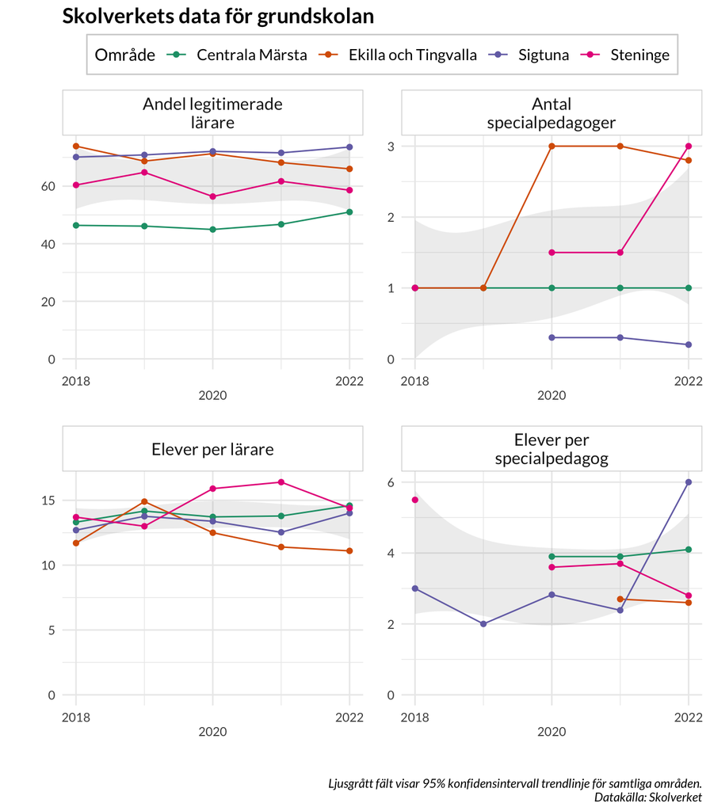

```r
gr.omr.sigtuna.sv %>%
  filter(description %in% c("Andel legitimerade lärare",
                            "Antal specialpedagoger",
                            "Elever per lärare",
                            "Elever per specialpedagog")) %>%
  DIDskolverketPlot() +
  scale_y_continuous(limits = c(0, NA))
```

**Andel elever med behörighet**

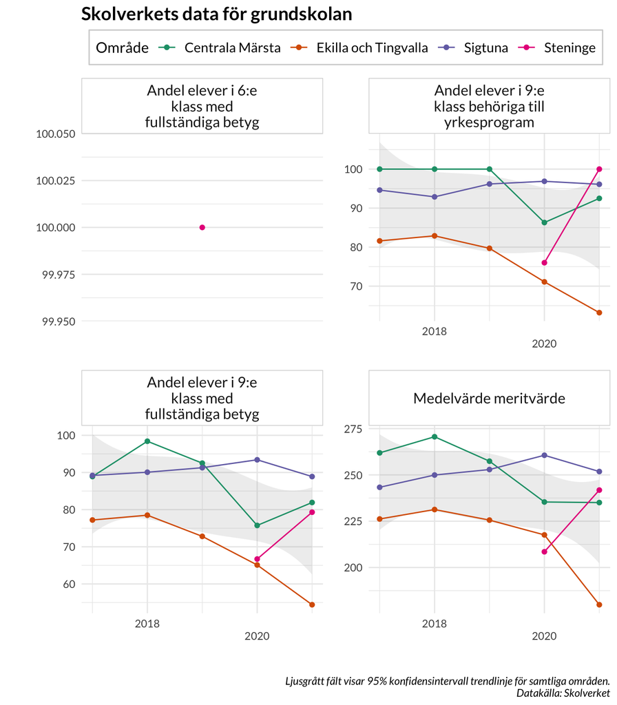

```r
gr.omr.sigtuna.sv %>%
  filter(description %in% c("Andel elever i 6:e klass med fullständiga betyg",
                            "Andel elever i 9:e klass med fullständiga betyg",
                            "Andel elever i 9:e klass behöriga till yrkesprogram",
                            "Medelvärde meritvärde")) %>%
  DIDskolverketPlot()
```

```r
#  scale_y_continuous(limits = c(0, 100))
```

**Medelvärde nationella prov**

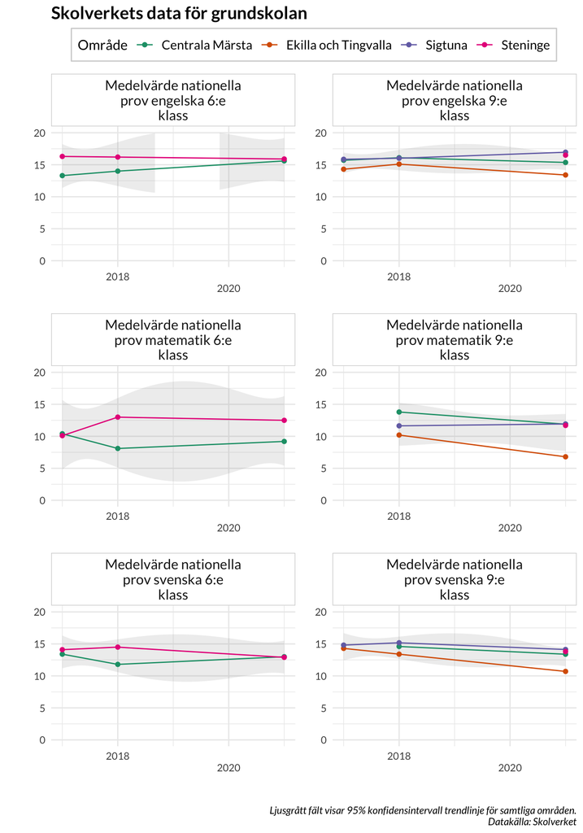

```r
gr.omr.sigtuna.sv %>%
  filter(description %in% c("Medelvärde nationella prov matematik 6:e klass",
                            "Medelvärde nationella prov matematik 9:e klass",
                            "Medelvärde nationella prov svenska 6:e klass",
                            "Medelvärde nationella prov svenska 9:e klass",
                            "Medelvärde nationella prov engelska 6:e klass",
                            "Medelvärde nationella prov engelska 9:e klass")) %>%
  DIDskolverketPlot() +
  scale_y_continuous(limits = c(0, 20))
```